# Assignment_3_Garima_Sharma

Garima Sharma MNumber: 08586245

November 19, 2015

**Question 1. Reading the Life Expectancy Data.**

```r
rm(list=ls())
origdata = read.csv("C:/Users/Garima/Downloads/data-table-B-16.csv", header = T)
```

Data imported in data frame `origdata`.

**Question 2. Plot and Explore Life Expectancy Data.**

```r
numberOfVariables <- ncol(origdata)
variableNames <- colnames(origdata)
numberOfObservations <- nrow(origdata)
```

Number of variables in Life Expectancy dataset is 6 and variable names are Country, LifeExp, People.per.TV, People.per.Dr, LifeExpMale, LifeExpFemale.

In Life Expectancy dataset, total number of observations are 38.

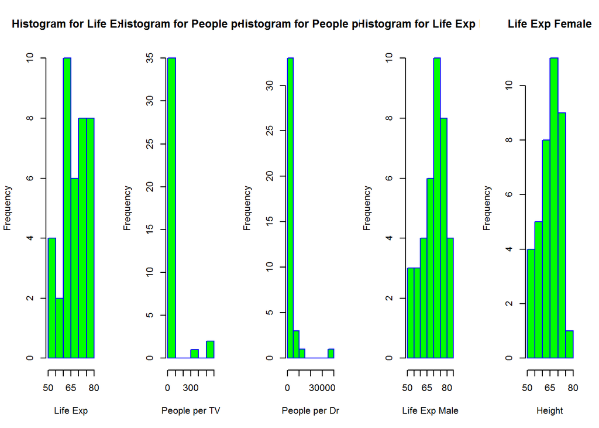

`pairs()` functionality can be used to plot the relatonship between these paramaters.

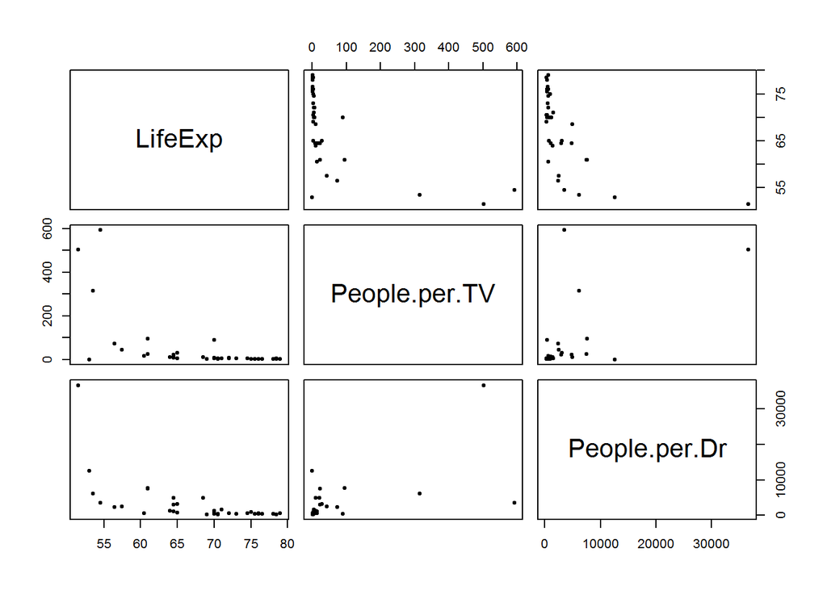

**Question 3. Building Multilinear Regression**

Multilinear Regression Model can be calculated using the equation:

y = $\beta_0$ + $\beta_1$*x1 + $\beta_2$*x2 + $\epsilon$

where y is ‘LifeExp’ x1 is ‘People-per-TV’ and x2 is ‘People-per-Dr’

**3.1 Obtaining Coefficient Estimates**

Calculating linear regression model using lm():

```r
frameData =data.frame(origdata$LifeExp,origdata$People.per.TV,origdata$People.per.Dr)
```

```r
modelLR <- lm(origdata$LifeExp ~ origdata$People.per.TV + origdata$People.per.Dr, data=frameData)
```

We can directly obtain the beta coefficient as

```r
modelLR$coefficients
```

```
##            (Intercept) origdata$People.per.TV origdata$People.per.Dr
##          70.2362645088          -0.0226073860          -0.0004470481
```

**3.2 95% Confidence Interval Estimation of Coefficients**

CI value can be calculated with a probability using the level of confidence which is given as (1-$\alpha$).

```r
beta0hat = modelLR$coefficients[1]
beta1hat = modelLR$coefficients[2]
beta2hat = modelLR$coefficients[3]
n = dim(origdata)[1]
k=2
p=3
alpha = 0.05
tCritical = qt(1-alpha/2, n-3)
sebeta0hat = summary(modelLR)$coef[1,2]
sebeta1hat = summary(modelLR)$coef[2,2]
sebeta2hat = summary(modelLR)$coef[3,2]
```

Confidence Intervals for Coefficients are given as:

68.018 <= $\beta_0$ <= 72.454

-0.042 <= $\beta_1$ <= -0.003

so it shows that population values of slope and intercept can be there in the range with a probability of 95%.

**3.3 T Test**

For equation y = $\beta_0$ + $\beta_1$*x1 + $\beta_2$*x2 + $\epsilon$

We will state the null hypothesis $H_0: \beta_1 = 0$ and $H_0: \beta_2 = 0$ and alternate hypotheis $H_1: \beta_1 != 0$ $H_2: \beta_2 != 0$.

Caluclating the T statistic and comparing it with the critical value of t, we can reject or fail to reject the above defined hypothesis.

The t-statistic is given as $t_0 = \beta_1 / SE(\beta_1)$

Reading the coefficients data from the output of `summary` functionality can directly provide us the t-statistic for our data as follows:

```r
summary(modelLR)$coef
```

```
##                             Estimate   Std. Error   t value     Pr(>|t|)
## (Intercept)            70.2362645088 1.0925483095 64.286644 6.330044e-38
## origdata$People.per.TV -0.0226073860 0.0096004611 -2.354823 2.426882e-02
## origdata$People.per.Dr -0.0004470481 0.0002016008 -2.217491 3.317745e-02
```

```r
alpha = 0.05
```

For Coefficient $\hat{\beta_1}$, t-statistic is -2.355, t critical is 2.0301079 and p value is 0.0242688.

While for Coefficient $\hat{\beta_2}$, t-statistic is -2.217, t critical is 2.0301079 and p value is 0.0331775.

Also, since the value calculated for p-values are less than $\alpha = 0.05$ so we can reject null hypothesis.

**3.4 F Test**

Null hypothesis is $H_0: \beta_1 = \beta_2 = 0$ and alternate hypothesis is $H_1: \beta_j != 0$ for at least one j.

| Source of variation | Sum of squares | DF | MS | F |
| --- | --- | --- | --- | --- |
| Regression | SSR | k | MSR=SSR/l | MSR/MSRES |
| Residual | SSRES | n-k-1 | MSRES=SSRES/(n-k-1) |  |
| Total | SST | n-1 |  |  |

Calculating SST, SSRES, SSR as described below, we can determine the F-statistic:

```r
colnames(frameData)=c("y","x1","x2")
```

```r
sstVal=sum((frameData$y-mean(frameData$y))^2)
```

SST: 2252.3684211

```r
ssresVal=sum((frameData$y-modelLR$fitted.values)^2)
```

SSRES: 1273.2730703

```r
ssrVal=sum((modelLR$fitted.values-mean(frameData$y))^2)
```

SSR: 979.0953507

```r
fVal=ssrVal/2/(ssresVal/(n-2-1))
```

F: 13.4567902

```r
fcritical = qf(alpha, k, n-p)
```

Comparing F with the critical value of F determined as 0.0513685.

Based on the values calculated, we can infer that F statistic calculated is greater than the F critical hence we can reject the null hypothesis.

Calculatin p value:

```r
pval = 1-pf(fVal, 1, n-k-1)
```

As we can see that p value is less than the value of alpha 0.05 hence we can reject the null hypothesis.

**3.5 Calculating SST, SSR and SSRES**

Definitions:

SSR is the sum of squares of Regression which provides the variance in the fitted value given by the summation of squares of difference between fitted y and mean y.

SSRES is the residual sum of squares which provides the the variance in the fitted value given by the summation of squares of difference between actual y values and fitted y values.

SST is the total sum of squares which provides the total variance in values of y from its mean given by the sum of SSR and SSRES.

```r
SST=sum((frameData$y-mean(frameData$y))^2)
SST
```

```
## [1] 2252.368
```

```r
SSRes=sum((frameData$y-modelLR$fitted.values)^2)
SSRes
```

```
## [1] 1273.273
```

```r
SSR=sum((modelLR$fitted.values-mean(frameData$y))^2)
SSR
```

```
## [1] 979.0954
```

**3.6 Coefficient of Determination R^2**

R^2 is the ratio of SSR to SST. It gives the variation provided by the independent variables i.e. R^2 = SSR/SST.

```r
RsquareVal = summary(modelLR)$r.square
```

R^2 = 0.4346959

**3.7 95% confidence interval for the fitted values (mean response)**

```r
confinterval=predict(modelLR,frameData,level=0.95,interval="confidence")
```

[output not shown]

Confidence Interval determines the range in which fitted value is determined for the values of independent variables with a probability of 100*(1-alpha).

**3.8 Predict life expectancy of a country with People.per.TV = 10 and People.per.Dr = 1000**

```r
colnames(frameData)=c("y","x1","x2")
modelLR <- lm(y ~ x1 + x2, data=frameData)
predVal1 = predict(modelLR,list(x1=10,x2=1000),interval="pred")
predVal1
```

```
##        fit      lwr      upr
## 1 69.56314 57.13846 81.98783
```

Prediction in multiple regression is extrapolated when the values of independent variables is beyond the region covering original observations.

```r
x0=c(1,10,1000)

column1 = rep(1, n)
column2 = frameData$x1
column3 = frameData$x2
X = matrix(c(column1, column2, column3), nrow=n)
```

```r
h00 = t(x0)%*%solve(t(X)%*%X)%*%x0
h00
```

```
##            [,1]
## [1,] 0.02962498
```

```r
H=X%*%solve(t(X)%*%X)%*%t(X)
hmaxVal = max(diag(H))
hmaxVal
```

```
## [1] 0.8227363
```

Since h00=0.029625 is less than hmax=0.8227363, so we have to do interpolation.

**3.9 Predict life expectancy with People.per.TV = 1000 and People.per.Dr = 50000**

```r
colnames(frameData)=c("y","x1","x2")
modelLR <- lm(y ~ x1 + x2, data=frameData)
predVal2 = predict(modelLR,list(x1=1000,x2=50000),interval="pred")
predVal2
```

```
##        fit      lwr      upr
## 1 25.27647 4.511533 46.04141
```

```r
x0=c(1,1000,50000)
column1 = rep(1, n)
column2 = frameData$x1
column3 = frameData$x2
X = matrix(c(column1, column2, column3), nrow=n)
h00 = t(x0)%*%solve(t(X)%*%X)%*%x0
h00
```

```
##          [,1]
## [1,] 1.875872
```

```r
H=X%*%solve(t(X)%*%X)%*%t(X)
hmaxValue = max(diag(H))
```

**3.10 Check Orthogonal - People.per.TV and People.per.Dr**

```r
modelVal1 <- lm(origdata$LifeExp ~ origdata$People.per.TV + origdata$People.per.Dr, data=frameData)
modelVal2 <- lm(origdata$LifeExp ~ origdata$People.per.TV, data=frameData)
modelVal3 <- lm(origdata$LifeExp ~ origdata$People.per.Dr, data=frameData)
modelVal1
```

```
##
## Call:
## lm(formula = origdata$LifeExp ~ origdata$People.per.TV + origdata$People.per.Dr,
##     data = frameData)
##
## Coefficients:
##            (Intercept)  origdata$People.per.TV  origdata$People.per.Dr
##              70.236265               -0.022607               -0.000447
```

```r
modelVal2
```

```
##
## Call:
## lm(formula = origdata$LifeExp ~ origdata$People.per.TV, data = frameData)
##
## Coefficients:
##            (Intercept)  origdata$People.per.TV
##               69.59362                -0.03563
```

```r
modelVal3
```

```
##
## Call:
## lm(formula = origdata$LifeExp ~ origdata$People.per.Dr, data = frameData)
##
## Coefficients:
##            (Intercept)  origdata$People.per.Dr
##             69.9264143              -0.0007374
```

If variables have individual explanatory power to derive the dependent variables then they are said to be orthogonal. We can determine that by the above approach:

**3.11 Standardized Regression Coefficients**

Unit length scaling

```r
unitlengthval = as.data.frame(apply(frameData,2,function(x){(x-mean(x))/sqrt(sum((x-mean(x))^2))}))
model1ULval <- lm(origdata$LifeExp ~ origdata$People.per.TV + origdata$People.per.Dr, data=unitlengthval)
model1ULval
```

```
##
## Call:
## lm(formula = origdata$LifeExp ~ origdata$People.per.TV + origdata$People.per.Dr,
##     data = unitlengthval)
##
## Coefficients:
##            (Intercept)  origdata$People.per.TV  origdata$People.per.Dr
##              70.236265               -0.022607               -0.000447
```

Unit Normal Scaling

```r
unitnormalval=as.data.frame(apply(frameData,2,function(x){(x-mean(x))/sd(x)}))
model1UNval <- lm(y ~ x1+x2, data=unitnormalval)
model1UNval
```

```
##
## Call:
## lm(formula = y ~ x1 + x2, data = unitnormalval)
##
## Coefficients:
## (Intercept)           x1           x2
##   8.701e-16   -3.782e-01   -3.562e-01
```

After the above calculation, we can determine that standardized coefficient of x1 and x2 are comparable and in similar range.

**3.12 Determination of multicollinearity issue in the data**

Multicolinearity exist if VIF > 10

```r
##library(car)
##vif(modelLR)
```

[output not shown]